# Project: Medical Appointments Attendance

- Introduction
- Data Wrangling
- Exploratory Data Analysis
- Conclusions

## Introduction

### Dataset Description

This dataset serves to study factors affecting attendance to medical appointments by patients in Brazil. Some of the key factors of analysis are gender, age and type of illness.

### Question(s) for Analysis

1. How well to patients respond to appointment attendance?
2. Does availability of scholarships affects attendance to appointments?
3. How does reception of SMS affect attendance to appointments?
4. what sickness are most patients registered for appointments diagnosed with?
5. What gender is more prone to sickness?
6. What are the range of ages for most patients registered for appointments

```python
import pandas as pd
import numpy as np
import matplotlib.pyplot as plt
import seaborn as sns
%matplotlib inline
```

## Data Wrangling

### General Properties

Load the csv file into your workspace and explore its properties

```python
df = pd.read_csv('noshowappointments-kagglev2-may-2016.csv')
```

```python
# To display the first 5 columns
df.head()
```

|  | PatientId | AppointmentID | Gender | ScheduledDay | AppointmentDay | Age | Neighbourhood | Scholarship | Hipertension | Diabetes | Alcoholism | Handcap | SMS_received | No-show |
| --- | --- | --- | --- | --- | --- | --- | --- | --- | --- | --- | --- | --- | --- | --- |
| 0 | 2.987250e+13 | 5642903 | F | 2016-04-29T18:38:08Z | 2016-04-29T00:00:00Z | 62 | JARDIM DA PENHA | 0 | 1 | 0 | 0 | 0 | 0 | No |
| 1 | 5.589978e+14 | 5642503 | M | 2016-04-29T16:08:27Z | 2016-04-29T00:00:00Z | 56 | JARDIM DA PENHA | 0 | 0 | 0 | 0 | 0 | 0 | No |
| 2 | 4.262962e+12 | 5642549 | F | 2016-04-29T16:19:04Z | 2016-04-29T00:00:00Z | 62 | MATA DA PRAIA | 0 | 0 | 0 | 0 | 0 | 0 | No |
| 3 | 8.679512e+11 | 5642828 | F | 2016-04-29T17:29:31Z | 2016-04-29T00:00:00Z | 8 | PONTAL DE CAMBURI | 0 | 0 | 0 | 0 | 0 | 0 | No |
| 4 | 8.841186e+12 | 5642494 | F | 2016-04-29T16:07:23Z | 2016-04-29T00:00:00Z | 56 | JARDIM DA PENHA | 0 | 1 | 1 | 0 | 0 | 0 | No |

```python
# To display the last five columns
df.tail()
```

|  | PatientId | AppointmentID | Gender | ScheduledDay | AppointmentDay | Age | Neighbourhood | Scholarship | Hipertension | Diabetes | Alcoholism | Handcap | SMS_received | No-show |
| --- | --- | --- | --- | --- | --- | --- | --- | --- | --- | --- | --- | --- | --- | --- |
| 110522 | 2.572134e+12 | 5651768 | F | 2016-05-03T09:15:35Z | 2016-06-07T00:00:00Z | 56 | MARIA ORTIZ | 0 | 0 | 0 | 0 | 0 | 1 | No |
| 110523 | 3.596266e+12 | 5650093 | F | 2016-05-03T07:27:33Z | 2016-06-07T00:00:00Z | 51 | MARIA ORTIZ | 0 | 0 | 0 | 0 | 0 | 1 | No |
| 110524 | 1.557663e+13 | 5630692 | F | 2016-04-27T16:03:52Z | 2016-06-07T00:00:00Z | 21 | MARIA ORTIZ | 0 | 0 | 0 | 0 | 0 | 1 | No |
| 110525 | 9.213493e+13 | 5630323 | F | 2016-04-27T15:09:23Z | 2016-06-07T00:00:00Z | 38 | MARIA ORTIZ | 0 | 0 | 0 | 0 | 0 | 1 | No |
| 110526 | 3.775115e+14 | 5629448 | F | 2016-04-27T13:30:56Z | 2016-06-07T00:00:00Z | 54 | MARIA ORTIZ | 0 | 0 | 0 | 0 | 0 | 1 | No |

#### A short description of column headings

- The columns headings represent the charactreristics of the patients that should be explored to determine the consistency of their attendance to appointments.
- The last column 'No -show' says 'No' if the patient showed up for their appointment and 'Yes' if they did not.
- ‘ScheduledDay’ tells us on what day the patient set up their appointment.
- ‘Neighborhood’ indicates the location of the hospital.
- ‘Scholarship’ indicates whether or not the patient is enrolled in Brasilian welfare program.

```python
df.shape
```

```
(110527, 14)
```

There are essentially 110527 patients registered for appointemnts, showed by the number of rows and 14 columns indicating patient characteristics.

```python
df.describe()
```

|  | PatientId | AppointmentID | Age | Scholarship | Hipertension | Diabetes | Alcoholism | Handcap | SMS_received |
| --- | --- | --- | --- | --- | --- | --- | --- | --- | --- |
| count | 1.105270e+05 | 1.105270e+05 | 110527.000000 | 110527.000000 | 110527.000000 | 110527.000000 | 110527.000000 | 110527.000000 | 110527.000000 |
| mean | 1.474963e+14 | 5.675305e+06 | 37.088874 | 0.098266 | 0.197246 | 0.071865 | 0.030400 | 0.022248 | 0.321026 |
| std | 2.560949e+14 | 7.129575e+04 | 23.110205 | 0.297675 | 0.397921 | 0.258265 | 0.171686 | 0.161543 | 0.466873 |
| min | 3.921784e+04 | 5.030230e+06 | -1.000000 | 0.000000 | 0.000000 | 0.000000 | 0.000000 | 0.000000 | 0.000000 |
| 25% | 4.172614e+12 | 5.640286e+06 | 18.000000 | 0.000000 | 0.000000 | 0.000000 | 0.000000 | 0.000000 | 0.000000 |
| 50% | 3.173184e+13 | 5.680573e+06 | 37.000000 | 0.000000 | 0.000000 | 0.000000 | 0.000000 | 0.000000 | 0.000000 |
| 75% | 9.439172e+13 | 5.725524e+06 | 55.000000 | 0.000000 | 0.000000 | 0.000000 | 0.000000 | 0.000000 | 1.000000 |
| max | 9.999816e+14 | 5.790484e+06 | 115.000000 | 1.000000 | 1.000000 | 1.000000 | 1.000000 | 4.000000 | 1.000000 |

```python
# Gives information on the dataset to aid in data cleaning
df.info()
```

```
<class 'pandas.core.frame.DataFrame'>
RangeIndex: 110527 entries, 0 to 110526
Data columns (total 14 columns):
 #   Column          Non-Null Count   Dtype
---  ------          --------------   -----
 0   PatientId       110527 non-null  float64
 1   AppointmentID   110527 non-null  int64
 2   Gender          110527 non-null  object
 3   ScheduledDay    110527 non-null  object
 4   AppointmentDay  110527 non-null  object
 5   Age             110527 non-null  int64
 6   Neighbourhood   110527 non-null  object
 7   Scholarship     110527 non-null  int64
 8   Hipertension    110527 non-null  int64
 9   Diabetes        110527 non-null  int64
 10  Alcoholism      110527 non-null  int64
 11  Handcap         110527 non-null  int64
 12  SMS_received    110527 non-null  int64
 13  No-show         110527 non-null  object
dtypes: float64(1), int64(8), object(5)
memory usage: 11.8+ MB
```

```python
df.duplicated()
```

```
0         False
1         False
2         False
3         False
4         False
          ...
110522     True
110523     True
110524     True
110525     True
110526     True
Length: 110527, dtype: bool
```

```python
# Gives the number of duplicate rows(attributes)
sum(df.duplicated())
```

[output not shown]

The above functions aid us in knowing the number of duplicate rows

### Data Cleaning

#### Dropping duplicate rows

The fuction below drops the duplicate rows

```python
df.drop_duplicates(inplace=True)
```

```python
# This is to determine how many rows are remaining
df.shape
```

[output not shown]

#### Dropping unnecessary columns for the analysis

Since there are no missing values in the dataset, I will go ahead to remove columns(attributes) I will not require in my analysis

```python
# This is to drop column names(attributes) not required in the analysis
df.drop(['PatientId', 'AppointmentID', 'Neighbourhood', 'ScheduledDay', 'AppointmentDay'], axis=1, inplace=True)
```

```python
# To display excerpt of dataset with deducted columns
df.head()
```

|  | Gender | Age | Scholarship | Hipertension | Diabetes | Alcoholism | Handcap | SMS_received | No-show |
| --- | --- | --- | --- | --- | --- | --- | --- | --- | --- |
| 0 | F | 62 | 0 | 1 | 0 | 0 | 0 | 0 | No |
| 1 | M | 56 | 0 | 0 | 0 | 0 | 0 | 0 | No |
| 2 | F | 62 | 0 | 0 | 0 | 0 | 0 | 0 | No |
| 3 | F | 8 | 0 | 0 | 0 | 0 | 0 | 0 | No |
| 4 | F | 56 | 0 | 1 | 1 | 0 | 0 | 0 | No |

#### Changing column data types

Since the integer values used in the illness columns only refer to the availability of the illness and have no actual numerical significance, it is proper to change them into strings. The same applies for 'SMS_received' column.

```python
df['Scholarship'] = df.Scholarship.astype(str)
df['Hipertension'] = df.Hipertension.astype(str)
df['Diabetes'] = df.Diabetes.astype(str)
df['Alcoholism'] = df.Alcoholism.astype(str)
df['Handcap'] = df.Handcap.astype(str)
df['SMS_received'] = df.SMS_received.astype(str)
```

```python
# To check the data type of each attribute
df.dtypes
```

```
Gender          object
Age              int64
Scholarship     object
Hipertension    object
Diabetes        object
Alcoholism      object
Handcap         object
SMS_received    object
No-show         object
dtype: object
```

## Exploratory Data Analysis

```python
# Most frequent plotting functions
def direct_plot(attribute):
    return df[attribute].value_counts(normalize=True).mul(100)
def groupby_plot(attribute1, attribute2):
    return df.groupby(attribute1)[attribute2].value_counts(normalize=True).mul(100).unstack().plot(kind='bar', rot=0, edgecolor='black', width=0.8, figsize=(10,6))
```

### How well do patients respond to appointment attendance?

To answer the above question, we have generate the statistics and visualizations of those who attended and those who did not.

```python
df['No-show'].value_counts()
```

```
No     88208
Yes    22319
Name: No-show, dtype: int64
```

'No' represents patients who attended their appointments while 'Yes' represents those who did not.

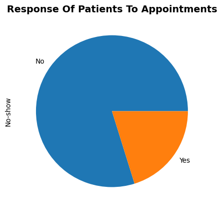

```python
direct_plot('No-show').plot(kind='pie', figsize=(14, 5));
plt.title('Response of patients to appointments'.title(), fontsize=14, weight='bold');
```

It is evident that a majority of the patients madee it to their appointments but a good number did not.

### Does availability of scholarships affect attendance to appointments?

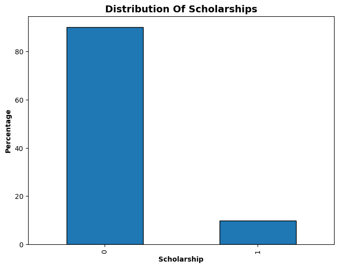

```python
direct_plot('Scholarship').plot(kind='bar', edgecolor='black', figsize=(8,6));
plt.title('Distribution of Scholarships'.title(), fontsize=14, weight='bold')
plt.xlabel('Scholarship'.title(), weight='bold', fontsize=10)
plt.ylabel('Percentage'.title(), weight='bold', fontsize=10);
```

'0' represents absensce of a scholarship while '1' represents presence of a scholarship. It is evident that a less number of resistered patients have scholarships. let us investigate how both types of patients respond to attendance to appointments...

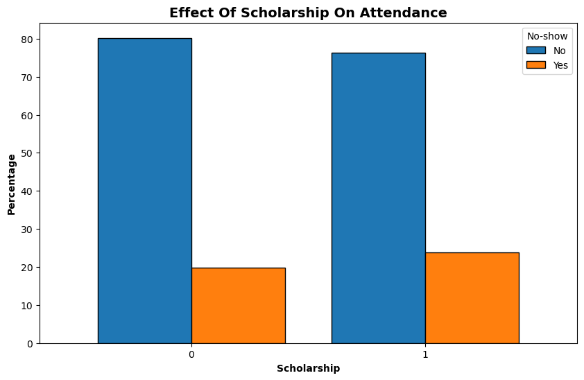

```python
groupby_plot('Scholarship', 'No-show')
plt.title('Effect of Scholarship on Attendance'.title(), weight='bold', fontsize=14)
plt.xlabel('Scholarship'.title(), weight='bold', fontsize=10)
plt.ylabel('Percentage'.title(), weight='bold', fontsize=10);
```

```python
pd.crosstab(index=df['No-show'], columns=df['Scholarship'])
```

| Scholarship No-show | 0 | 1 |
| --- | --- | --- |
| No | 79925 | 8283 |
| Yes | 19741 | 2578 |

The above serves as backup statistics to the visualization above.

### What sickness are most patients registered for appointments diagnosed with?

Overall '0' represents absence of the specific illness while '1' signifies its presence except for handcap where the numbers have significance such that '0' represents no areas with handicap, '1' represents 1 area with handicap and so forth.

```python
# Statistics of patients with Hipertension
df['Hipertension'].value_counts()
```

```
0    88726
1    21801
Name: Hipertension, dtype: int64
```

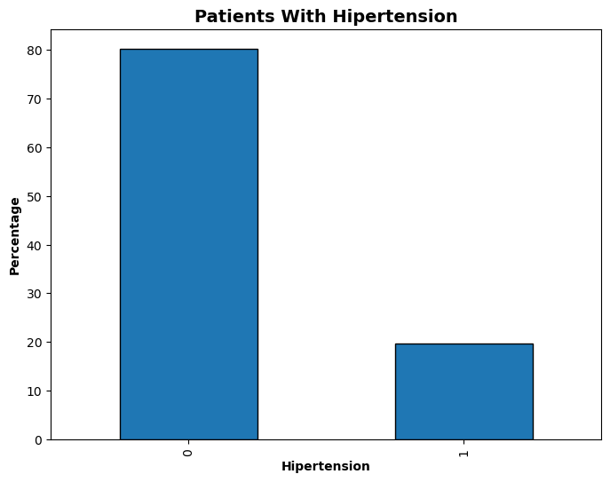

```python
# A visual of patients with hipertension
direct_plot('Hipertension').plot(kind='bar', edgecolor='black', figsize=(8, 6));
plt.title('Patients with Hipertension'.title(), weight='bold', fontsize=14)
plt.xlabel('Hipertension'.title(), weight='bold', fontsize=10)
plt.ylabel('percentage'.title(), weight='bold', fontsize=10)
```

```python
# Statistics of patients with diabetes
df['Diabetes'].value_counts()
```

```
0    102584
1      7943
Name: Diabetes, dtype: int64
```

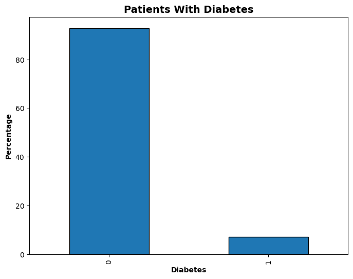

```python
# Visual of patients with diabetes
direct_plot('Diabetes').plot(kind='bar', edgecolor='black', figsize=(8, 6));
plt.title('Patients with Diabetes'.title(), weight='bold', fontsize=14)
plt.xlabel('Diabetes'.title(), weight='bold', fontsize=10)
plt.ylabel('percentage'.title(), weight='bold', fontsize=10)
```

```python
# Statistics of patients suffering from alcoholism
df['Alcoholism'].value_counts()
```

```
0    107167
1      3360
Name: Alcoholism, dtype: int64
```

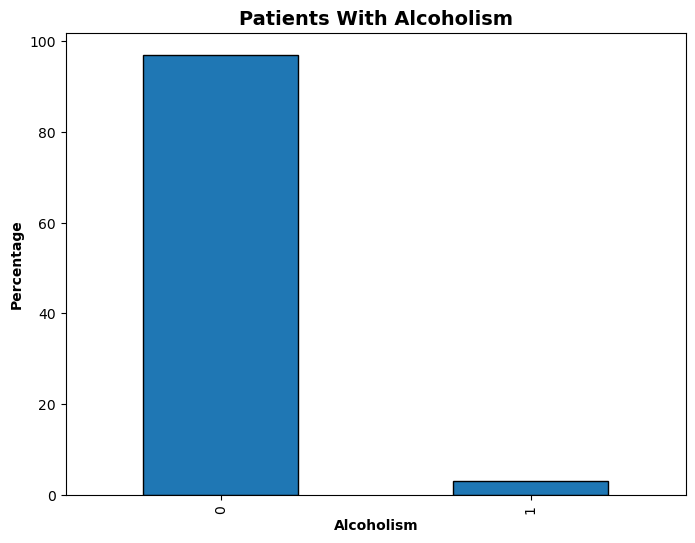

```python
# A visual of patients with alcoholism
direct_plot('Alcoholism').plot(kind='bar', edgecolor='black', figsize=(8, 6));
plt.title('Patients with Alcoholism'.title(), weight='bold', fontsize=14)
plt.xlabel('Alcoholism'.title(), weight='bold', fontsize=10)
plt.ylabel('percentage'.title(), weight='bold', fontsize=10)
```

```python
df['Handcap'].value_counts()
```

```
0    108286
1      2042
2       183
3        13
4         3
Name: Handcap, dtype: int64
```

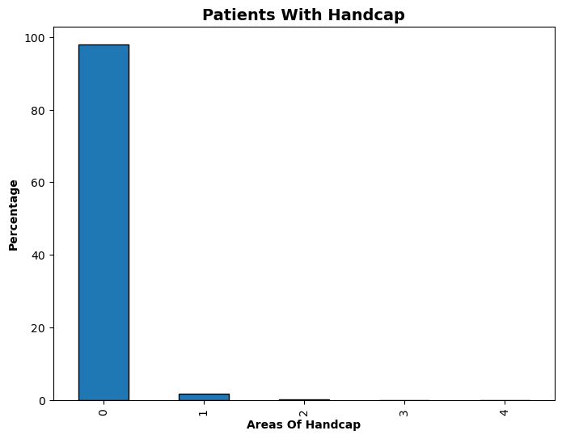

```python
direct_plot('Handcap').plot(kind='bar', edgecolor='black', figsize=(8, 6));
plt.title('Patients with Handcap'.title(), weight='bold', fontsize=14)
plt.xlabel('Areas of Handcap'.title(), weight='bold', fontsize=10)
plt.ylabel('percentage'.title(), weight='bold', fontsize=10)
```

### How does reception of SMS affect attendance to appointments?

Let us first have a look at the difference in numbers between those who got SMS and those who did not. '1' represents those who received the SMS while '0' represents those who did not.

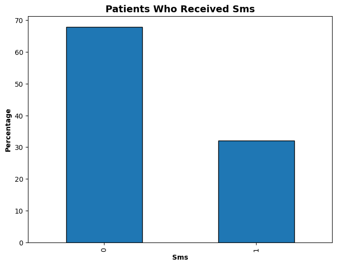

```python
direct_plot('SMS_received').plot(kind='bar', edgecolor='black', figsize=(8, 6));
plt.title('Patients who received SMS'.title(), weight='bold', fontsize=14)
plt.xlabel('SMS'.title(), weight='bold', fontsize=10)
plt.ylabel('percentage'.title(), weight='bold', fontsize=10)
```

```python
# statistics of those who received an sms
df.SMS_received.value_counts()
```

```
0    75045
1    35482
Name: SMS_received, dtype: int64
```

Let us now examine how many of those who received SMS attended their appointments in contrast to others.

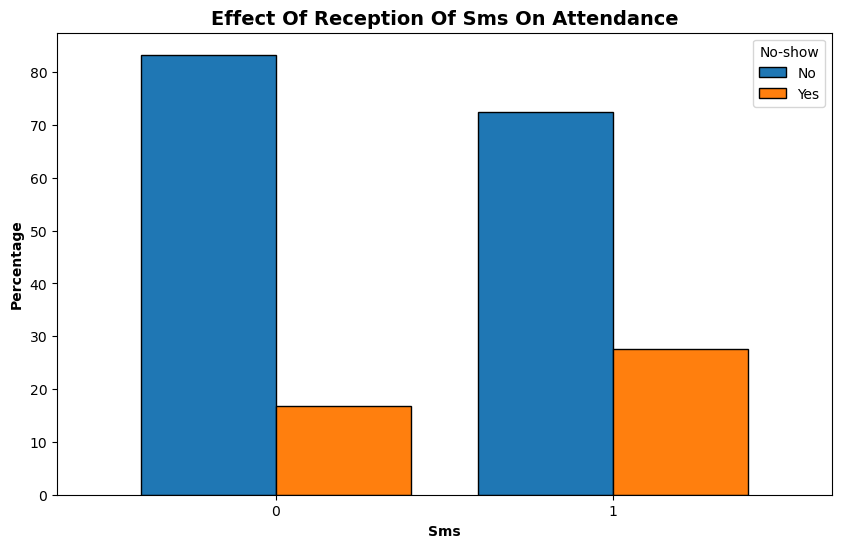

```python
# 'No' represents those who showed up for their appointments while 'Yes' represents those who did not.
groupby_plot('SMS_received', 'No-show')
plt.title('Effect of Reception of SMS on Attendance'.title(), weight='bold', fontsize=14)
plt.xlabel('SMS'.title(), weight='bold', fontsize=10)
plt.ylabel('Percentage'.title(), weight='bold', fontsize=10)
```

### Is gender associated with appointment attendance?

First let us explore the number of men and women registered for appointments. F represents 'Female' while M reprsents 'Male'.

```python
df.Gender.value_counts()
```

```
F    71840
M    38687
Name: Gender, dtype: int64
```

#### Which gender is more prone to sickness?

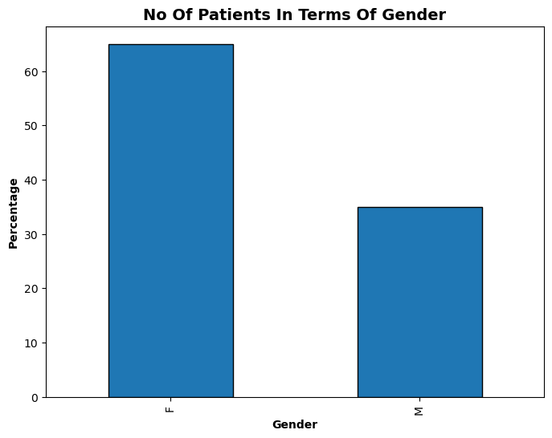

```python
direct_plot('Gender').plot(kind='bar', edgecolor='black', figsize=(8, 6));
plt.title('No of Patients in terms of Gender'.title(), weight='bold', fontsize=14)
plt.xlabel('Gender'.title(), weight='bold', fontsize=10)
plt.ylabel('percentage'.title(), weight='bold', fontsize=10)
```

It is evident that more women were registered for the appointments than men. It may also signify women are more prone to illnesses than men.

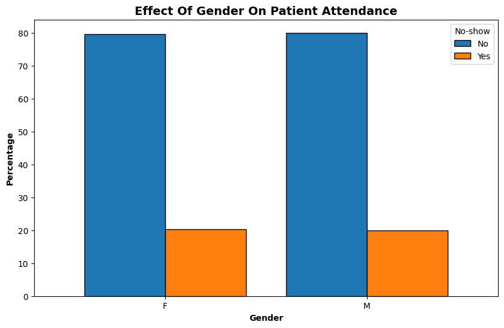

```python
groupby_plot('Gender', 'No-show');
plt.title('Effect of Gender on Patient Attendance'.title(), weight='bold', fontsize=14);
plt.xlabel('Gender'.title(), weight='bold', fontsize=10);
plt.ylabel('Percentage'.title(), weight='bold', fontsize=10);
```

```python
pd.crosstab(index=df['No-show'], columns=df['Gender'])
```

| Gender No-show | F | M |
| --- | --- | --- |
| No | 57246 | 30962 |
| Yes | 14594 | 7725 |

The above are detailed stastics of the appointment attendance of both males and females. They seem to have an almost equal level of attendace.

### What are the range of ages for most patients registered for appointments

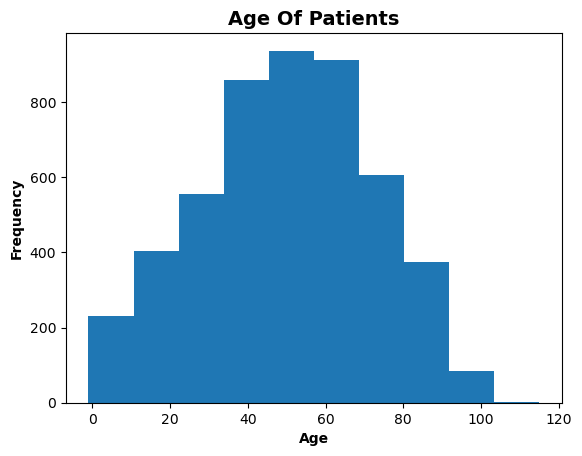

```python
df['Age'].plot(kind='hist')
plt.title('Age of Patients'.title(), fontsize=14, weight='bold')
plt.xlabel('Age'.title(), weight='bold', fontsize=10)
plt.ylabel('Frequency'.title(), weight='bold', fontsize=10)
```

It is evident that most patients registered for appointments are middle aged: between the age of 30 and 70 years.